# Week8

Shrey Kothari

2025-11-21

Step 1:

```r
library(tidyverse)
data <- read_csv("cox-violent-parsed.csv")
```

```
## ──────────────────────────────────────────────────────── Delimiter: "," chr
## (33): name, first, last, compas_screening_date, sex, dob, age_cat, race,... dbl
## (18): id, age, juv_fel_count, decile_score...12, juv_misd_count, juv_oth... lgl
## (1): violent_recid
```

```r
set.seed(862331611)
rows <- nrow(data)
trainIndex <- sample(1:rows, size = 0.7*rows)
trainData <- data[trainIndex, ]
testData <- data[-trainIndex, ]
trainData <- trainData %>%
  rename(priors_count = priors_count...15)
testData <- testData %>%
  rename(priors_count = priors_count...15)
trainData <- trainData %>%
  rename(decile_score = decile_score...12)
testData <- testData %>%
  rename(decile_score = decile_score...12)
```

```r
variablesOfInterest <- c("is_recid", "race", "age", "priors_count", "juv_fel_count", "decile_score")
df <- trainData[, variablesOfInterest]
model <- lm(is_recid ~ race + juv_fel_count + age + priors_count + decile_score, data = df)
summary(model)
```

```
##
## Call:
## lm(formula = is_recid ~ race + juv_fel_count + age + priors_count +
##     decile_score, data = df)
##
## Residuals:
##     Min      1Q  Median      3Q     Max
## -1.5262 -0.3845 -0.1047  0.5045  1.2505
##
## Coefficients:
##                       Estimate Std. Error t value Pr(>|t|)
## (Intercept)          0.4690088  0.0222794  21.051  < 2e-16 ***
## raceAsian           -0.1909657  0.0785972  -2.430 0.015126 *
## raceCaucasian        0.0070139  0.0109581   0.640 0.522141
## raceHispanic        -0.0705612  0.0183783  -3.839 0.000124 ***
## raceNative American -0.0735624  0.0871630  -0.844 0.398705
## raceOther            0.0154399  0.0234510   0.658 0.510300
## juv_fel_count       -0.0001634  0.0101137  -0.016 0.987111
## age                 -0.0077999  0.0004758 -16.393  < 2e-16 ***
## priors_count         0.0293666  0.0010848  27.070  < 2e-16 ***
## decile_score         0.0205408  0.0020840   9.856  < 2e-16 ***
## ---
## Signif. codes:  0 '***' 0.001 '**' 0.01 '*' 0.05 '.' 0.1 ' ' 1
##
## Residual standard error: 0.5357 on 12811 degrees of freedom
## Multiple R-squared:  0.1324, Adjusted R-squared:  0.1318
## F-statistic: 217.2 on 9 and 12811 DF,  p-value: < 2.2e-16
```

Step 2:

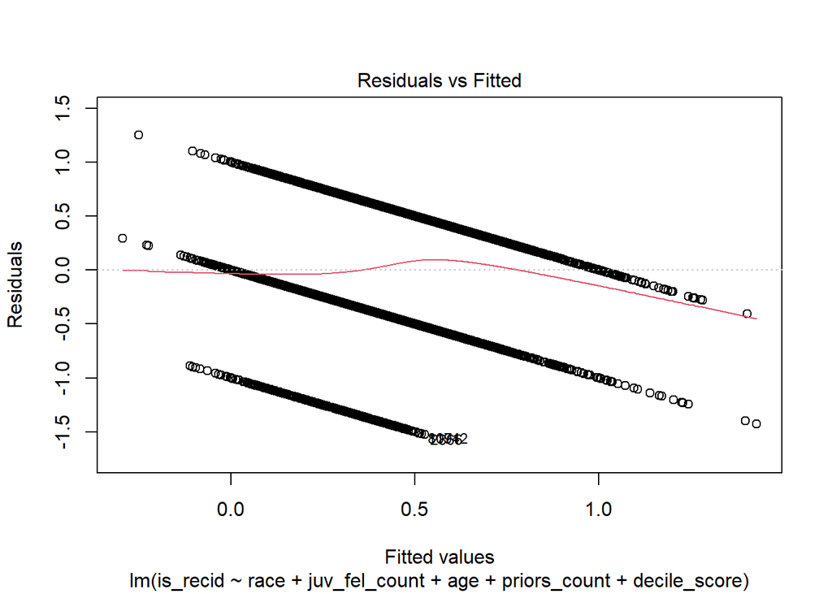

```r
plot(model, which = 1)
```

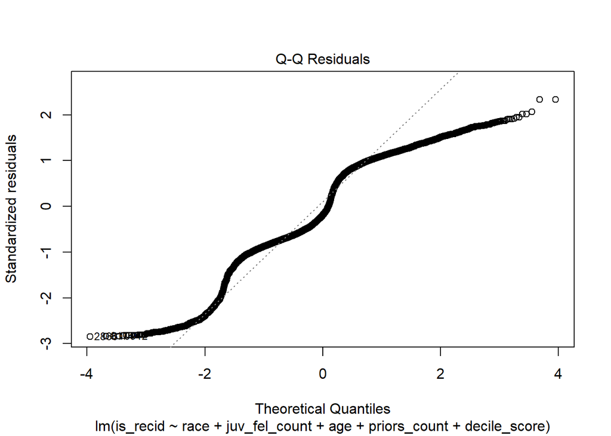

```r
plot(model, which = 2)
```

```r
df$age <- df$age - mean(df$age)
df$priors_count <- df$priors_count - mean(df$priors_count)
df$juv_fel_count <- df$juv_fel_count - mean(df$juv_fel_count)

model2 <- lm(is_recid ~ race + age + I(age^2) + juv_fel_count + I(juv_fel_count^2) + priors_count +I(priors_count^2) + decile_score, data = df)
summary(model2)
```

```
##
## Call:
## lm(formula = is_recid ~ race + age + I(age^2) + juv_fel_count +
##     I(juv_fel_count^2) + priors_count + I(priors_count^2) + decile_score,
##     data = df)
##
## Residuals:
##      Min       1Q   Median       3Q      Max
## -1.49152 -0.37850 -0.05849  0.47545  1.07199
##
## Coefficients:
##                       Estimate Std. Error t value Pr(>|t|)
## (Intercept)          3.771e-01  1.375e-02  27.424  < 2e-16 ***
## raceAsian           -1.590e-01  7.749e-02  -2.052  0.04018 *
## raceCaucasian        1.741e-02  1.082e-02   1.609  0.10761
## raceHispanic        -5.758e-02  1.813e-02  -3.177  0.00149 **
## raceNative American -1.825e-02  8.596e-02  -0.212  0.83188
## raceOther            3.264e-02  2.315e-02   1.410  0.15859
## age                 -1.196e-02  6.283e-04 -19.040  < 2e-16 ***
## I(age^2)             2.719e-04  3.096e-05   8.781  < 2e-16 ***
## juv_fel_count       -4.566e-03  1.482e-02  -0.308  0.75805
## I(juv_fel_count^2)  -5.822e-04  1.586e-03  -0.367  0.71360
## priors_count         5.465e-02  1.693e-03  32.277  < 2e-16 ***
## I(priors_count^2)   -1.856e-03  1.007e-04 -18.436  < 2e-16 ***
## decile_score         1.087e-02  2.128e-03   5.110 3.27e-07 ***
## ---
## Signif. codes:  0 '***' 0.001 '**' 0.01 '*' 0.05 '.' 0.1 ' ' 1
##
## Residual standard error: 0.528 on 12808 degrees of freedom
## Multiple R-squared:  0.1573, Adjusted R-squared:  0.1565
## F-statistic: 199.3 on 12 and 12808 DF,  p-value: < 2.2e-16
```

```r
adj_r_squared <- summary(model2)$adj.r.squared
adj_r_squared
```

```
## [1] 0.1565301
```

```r
library(car)
vif(model2)
```

```
##                        GVIF Df GVIF^(1/(2*Df))
## race               1.157561  5        1.014739
## age                2.477459  1        1.573995
## I(age^2)           1.885077  1        1.372981
## juv_fel_count      2.326464  1        1.525275
## I(juv_fel_count^2) 2.227902  1        1.492616
## priors_count       3.654053  1        1.911558
## I(priors_count^2)  2.727646  1        1.651559
## decile_score       1.790221  1        1.337991
```

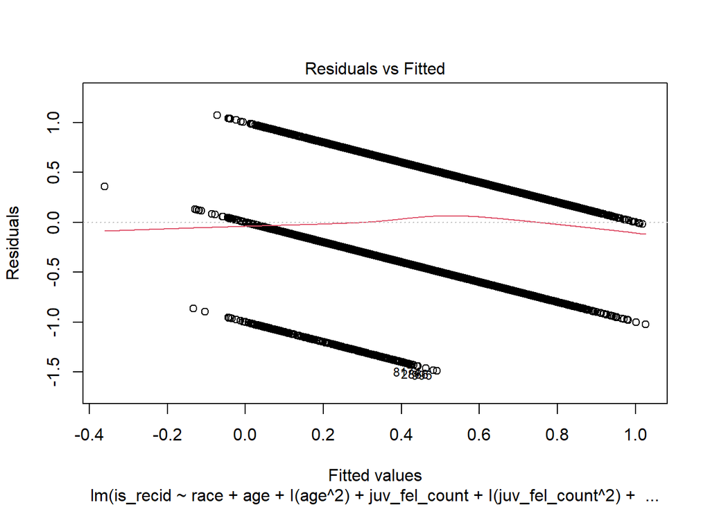

```r
plot(model2, which = 1)
```

We see that in the new residuals vs fitted graph, the curvature has improved the model because the curve is nearly flat, as opposed to the line shown in the first residuals vs fitted graph.

Step 3:

One interaction I am considering between two quantitative predictors would be age and juv_fel_count. Another interaction I am considering between a quantitative and a qualitative predictor would be race and priors_count.

The interaction between age and juv_fel_count is important because the effect of having felony charges as a juvenile may vary depending on an individual’s age. Similarly, the interaction between race and priors_count allows the model to capture differences in how prior offenses influence risk of being arrested again across racial groups. Including these interactions helps the model better reflect realistic variations and improves its accuracy.

```r
model3 <- lm(is_recid ~ race + age + I(age^2) + juv_fel_count + I(juv_fel_count^2) + priors_count + I(priors_count^2) + decile_score + age*juv_fel_count + race*priors_count, data = df)
summary(model3)
```

```
##
## Call:
## lm(formula = is_recid ~ race + age + I(age^2) + juv_fel_count +
##     I(juv_fel_count^2) + priors_count + I(priors_count^2) + decile_score +
##     age * juv_fel_count + race * priors_count, data = df)
##
## Residuals:
##      Min       1Q   Median       3Q      Max
## -1.49731 -0.37813 -0.05311  0.46756  1.08648
##
## Coefficients:
##                                    Estimate Std. Error t value Pr(>|t|)
## (Intercept)                       0.3822571  0.0137653  27.770  < 2e-16 ***
## raceAsian                         0.2218882  0.1430383   1.551 0.120867
## raceCaucasian                     0.0174954  0.0108637   1.610 0.107326
## raceHispanic                     -0.0487429  0.0197033  -2.474 0.013380 *
## raceNative American              -0.0470357  0.0876113  -0.537 0.591368
## raceOther                         0.0544475  0.0246993   2.204 0.027513 *
## age                              -0.0119378  0.0006280 -19.009  < 2e-16 ***
## I(age^2)                          0.0002614  0.0000312   8.379  < 2e-16 ***
## juv_fel_count                    -0.0070612  0.0153496  -0.460 0.645508
## I(juv_fel_count^2)               -0.0023367  0.0016545  -1.412 0.157871
## priors_count                      0.0518618  0.0018470  28.079  < 2e-16 ***
## I(priors_count^2)                -0.0018140  0.0001018 -17.821  < 2e-16 ***
## decile_score                      0.0103750  0.0021268   4.878 1.08e-06 ***
## age:juv_fel_count                -0.0028408  0.0013110  -2.167 0.030256 *
## raceAsian:priors_count            0.1397159  0.0429240   3.255 0.001137 **
## raceCaucasian:priors_count        0.0060843  0.0021933   2.774 0.005544 **
## raceHispanic:priors_count         0.0101357  0.0050068   2.024 0.042951 *
## raceNative American:priors_count  0.0236741  0.0108301   2.186 0.028836 *
## raceOther:priors_count            0.0177772  0.0053846   3.302 0.000964 ***
## ---
## Signif. codes:  0 '***' 0.001 '**' 0.01 '*' 0.05 '.' 0.1 ' ' 1
##
## Residual standard error: 0.5273 on 12802 degrees of freedom
## Multiple R-squared:  0.1598, Adjusted R-squared:  0.1587
## F-statistic: 135.3 on 18 and 12802 DF,  p-value: < 2.2e-16
```

Based on the model, the interaction between age and juv_fel_count is statistically significant because the p-value is equal to 0.030256. Due to the same reason with different p-values, the interaction between race and priors_count is statistically significant because each p value is below 0.05. We do see that both interactions improve fit with an increase in Adjusted R^2 and improves interpretability.

Step 4:

No, the expanded model is not too large for the sample size.

Step 5:

Our response variable Y is not strictly positive. None of the predictors require additional transformations. This is because we are already covering curvatures and non-linearity in the squared terms. It is also because we can not perform transformations on some predictors, such as decile score and race.

Step 6:

```r
model_final <- lm(is_recid ~ race + age + I(age^2) + juv_fel_count + I(juv_fel_count^2) + priors_count + I(priors_count^2) + decile_score + age*juv_fel_count + race*priors_count, data = df)
summary(model_final)
```

```
##
## Call:
## lm(formula = is_recid ~ race + age + I(age^2) + juv_fel_count +
##     I(juv_fel_count^2) + priors_count + I(priors_count^2) + decile_score +
##     age * juv_fel_count + race * priors_count, data = df)
##
## Residuals:
##      Min       1Q   Median       3Q      Max
## -1.49731 -0.37813 -0.05311  0.46756  1.08648
##
## Coefficients:
##                                    Estimate Std. Error t value Pr(>|t|)
## (Intercept)                       0.3822571  0.0137653  27.770  < 2e-16 ***
## raceAsian                         0.2218882  0.1430383   1.551 0.120867
## raceCaucasian                     0.0174954  0.0108637   1.610 0.107326
## raceHispanic                     -0.0487429  0.0197033  -2.474 0.013380 *
## raceNative American              -0.0470357  0.0876113  -0.537 0.591368
## raceOther                         0.0544475  0.0246993   2.204 0.027513 *
## age                              -0.0119378  0.0006280 -19.009  < 2e-16 ***
## I(age^2)                          0.0002614  0.0000312   8.379  < 2e-16 ***
## juv_fel_count                    -0.0070612  0.0153496  -0.460 0.645508
## I(juv_fel_count^2)               -0.0023367  0.0016545  -1.412 0.157871
## priors_count                      0.0518618  0.0018470  28.079  < 2e-16 ***
## I(priors_count^2)                -0.0018140  0.0001018 -17.821  < 2e-16 ***
## decile_score                      0.0103750  0.0021268   4.878 1.08e-06 ***
## age:juv_fel_count                -0.0028408  0.0013110  -2.167 0.030256 *
## raceAsian:priors_count            0.1397159  0.0429240   3.255 0.001137 **
## raceCaucasian:priors_count        0.0060843  0.0021933   2.774 0.005544 **
## raceHispanic:priors_count         0.0101357  0.0050068   2.024 0.042951 *
## raceNative American:priors_count  0.0236741  0.0108301   2.186 0.028836 *
## raceOther:priors_count            0.0177772  0.0053846   3.302 0.000964 ***
## ---
## Signif. codes:  0 '***' 0.001 '**' 0.01 '*' 0.05 '.' 0.1 ' ' 1
##
## Residual standard error: 0.5273 on 12802 degrees of freedom
## Multiple R-squared:  0.1598, Adjusted R-squared:  0.1587
## F-statistic: 135.3 on 18 and 12802 DF,  p-value: < 2.2e-16
```

```r
vif(model_final)
```

```
## there are higher-order terms (interactions) in this model
## consider setting type = 'predictor'; see ?vif
```

```
##                        GVIF Df GVIF^(1/(2*Df))
## race               5.862358  5        1.193458
## age                2.481138  1        1.575163
## I(age^2)           1.918981  1        1.385273
## juv_fel_count      2.501462  1        1.581601
## I(juv_fel_count^2) 2.429767  1        1.558771
## priors_count       4.359847  1        2.088025
## I(priors_count^2)  2.795128  1        1.671864
## decile_score       1.793486  1        1.339211
## age:juv_fel_count  1.510362  1        1.228968
## race:priors_count  8.125272  5        1.233059
```

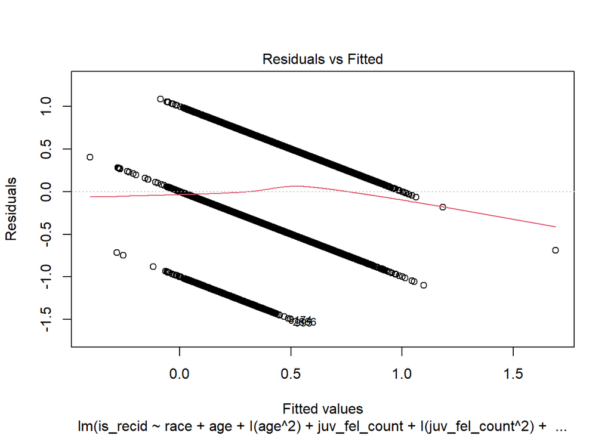

```r
plot(model_final, which = 1)
```

The Adjusted R^2 is equal to 0.1587, which means that the model explains 15.87 percent of the variance while accounting for the number of predictors.

For VIF, we do see that race and the interaction between race and priors_count have values over 5, which means that we do have some multicollinearity concerns.

In the residuals vs fitted values plot, we do see that the line has gone away from 0 again. This is most likely due to the categorical variable “race” and its interaction.

Step 7:

```r
pred_test <- predict(model_final, newdata = testData)
RMSE <- sqrt(mean((testData$is_recid - pred_test)^2))
RMSE
```

```
## [1] 0.5853634
```